# Practical mashine learning course project

Kristijonas Impolevičius

10/10/2015

# Problem formulation

## introduction

Data is from accelerometers. We will try create model which will predict the manner participants did their exersises.

## Model selection

Here the task is to predict the classe (quality value).  
So this is a supervised learning and multi-clasification problem.

## Data preparation for machine learning

Data is taken from this link ‘https://d396qusza40orc.cloudfront.net/predmachlearn/pml-training.csv’.

### Data import step

Data import step is not included here but you can view it in .RMD file.

### Data structure

Data is a table with 160 columns and 19622 rows. Data is separated into windows. Each window is accelerator observation session. Each session has a summary line. When session (window) ends, summary columns are calculated and added. This is new_window == “yes” row in data frame.

### Columns discarded

The data has some columns which are not needed. They are just details of experiment, but not the observation of the accelerator. So there is X (which is just a primary_key ), user_name, raw_timestamp_part_1, raw_timestamp_part_2, cvtd_timestamp, new_window, num_window.

There are summary columns calculated at each session end. Summary columns are not interesting to our prediction vector, so these summary columns are also discarded. Summary columns has extention like ’_total’, ’_max’, ’_min’ and so on.

Data cleaning step is not included here, but you can view in in .RMD file.

### Extending Data

This study will update data by creating new columns, which will be polynomial. In this study every column (exept classe) will be updated up to degree of 10.

Here is code for doing that.

```r
poly.degree = 10

table.poly <- as.data.frame(t(apply(table.cleaned[,c(-49)],1,poly,degree=poly.degree,raw=TRUE)))
names.of.poly <- names(table.cleaned[,c(-49)])
for(i in 2:poly.degree){
    names.of.poly <- c(names.of.poly,paste(names(table.cleaned[,c(-49)]),"_d",i,sep = ""))
}
names(table.poly) <- names.of.poly
table.poly <- cbind(table.poly,classe=table.cleaned$classe)
```

Now data has 481 columns.

## Machine learning

### Model selection

It is multi-classification problem. And this report will try to fit model. We’ll fit model of various degrees. In this study linear models and non linear models will be tryed.  
This report will investigate which model will be best for prediction.

### Which models will be considered

These models will be considered. Linear models  
1. Linear discriminant analysis (LDA) with polynomial features 1-10.  
2. Quadratic discriminant analysis (QDA) with polynomial features 1-3.  
Non linear models  
3. Random forest  
4. Boosting

### Choosing the best model

For each model we’ll measuse accuracy for validation set. The best model will be which accuracy will be highest for validation set. If model accuracy will be about the same we will choose model which requires less training time.

### How all this will work

Fore every model this study will do steps:  
1. train model with table.poly table  
2. calculate confusion matrix for training data  
3. calculate confusion matrix for validation set  
4. Come with inferences

### Set seed

For reproducibility we set seed 2222.

```r
set.seed(2222)
```

### Train and validation sets

We split our data to validation set and training set. The test set is given and this study will try to predict given test data. In this study 75% of data will be for training and 25% for validation.

```r
sample.size = round(.75*dim(table.poly)[1])
train.sample = sample(dim(table.poly)[1],sample.size)

indexes <- seq(1:dim(table.poly)[1])
indexTrue <- indexes %in% train.sample

train.table <- table.poly[indexTrue,]
validation.table <- table.poly[!indexTrue,]
```

## Linear discriminant analysis

This study will do LDA models with various polynomial degrees and will investigate which degree is best. Here is code which trains data with various degrees.

```r
list.lda.models = list()
list.lda.models.CM.train = list()
list.lda.models.CM.validation = list()
for ( i in 1:poly.degree){

    list.lda.models[[i]] <- lda(
        classe~.,
        dplyr::select(train.table,c(1:{48*i},{48*poly.degree+1}))
    )

    prediction.1.train <- predict(list.lda.models[[i]],newdata=train.table)
    prediction.1.validation <- predict(list.lda.models[[i]],newdata=validation.table)

    list.lda.models.CM.train[[i]] <- confusionMatrix(
        prediction.1.train$class,train.table$classe)
    list.lda.models.CM.validation[[i]] <- confusionMatrix(
        prediction.1.validation$class,validation.table$classe)

}
```

Accuracy

| degree | train | validation |
| --- | --- | --- |
| 1 | 0.694 | 0.696 |
| 2 | 0.822 | 0.822 |
| 3 | 0.863 | 0.857 |
| 4 | 0.888 | 0.883 |
| 5 | 0.902 | 0.893 |
| 6 | 0.914 | 0.908 |
| 7 | 0.919 | 0.912 |
| 8 | 0.926 | 0.918 |
| 9 | 0.932 | 0.921 |
| 10 | 0.936 | 0.925 |

We see that more degree gives us more accuraccy.

Here is graph showing misclassification error for train and validation data.

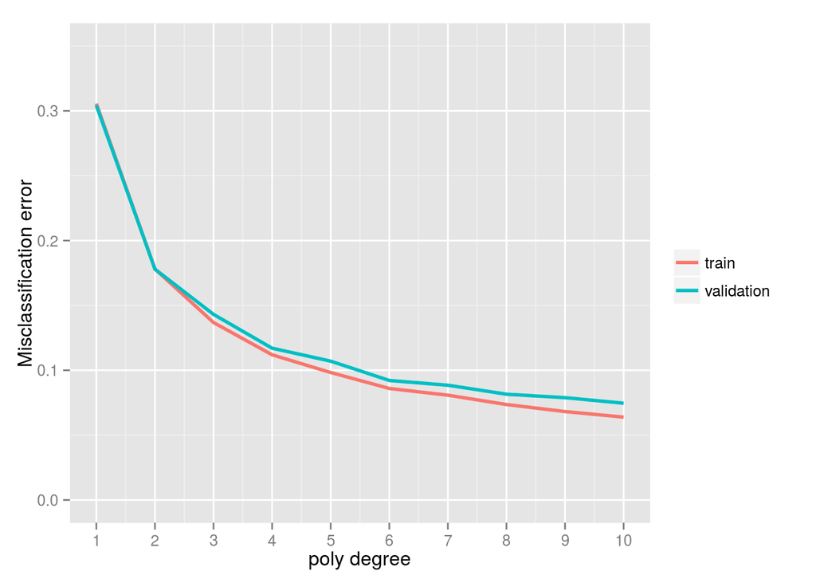

### LDA conclusions

Here is final model on LDA. This report shows that if more degree are introduced, the model better fits.  
And even from validation error the more degrees do not lead to overfitting. This study managed to achieve misclassification error less than 0.1, but this report will show, that better results can be achieved.

Here are results for level 10 degree model.

Metrix

| Accuracy | Kappa | AccuracyLower | AccuracyUpper | AccuracyNull | AccuracyPValue | McnemarPValue |
| --- | --- | --- | --- | --- | --- | --- |
| 0.925 | 0.906 | 0.918 | 0.933 | 0.285 | 0 | 0 |

Confusion matrix

|  | A | B | C | D | E |
| --- | --- | --- | --- | --- | --- |
| A | 1365 | 45 | 0 | 0 | 0 |
| B | 16 | 858 | 36 | 11 | 18 |
| C | 10 | 34 | 780 | 81 | 57 |
| D | 5 | 7 | 15 | 698 | 27 |
| E | 1 | 1 | 1 | 1 | 839 |

## Quadratic discriminant analysis

This is the same situation like LDA. But it creates model only until degree 3. Later it gives some R errors. So we’ll train only 3 models and compare which is best. Here is code to train these 3 models.

```r
list.qda.models = list()
list.qda.models.CM.train = list()
list.qda.models.CM.validation = list()
for ( i in 1:3){
    try(
        {
        list.qda.models[[i]] <- qda(
            classe~.,
            dplyr::select(train.table,c(1:{48*i},{48*poly.degree+1}))
        )

        prediction.train <- predict(list.qda.models[[i]],newdata=train.table)
        prediction.validation <- predict(list.qda.models[[i]],newdata=validation.table)

        list.qda.models.CM.train[[i]] <- confusionMatrix(
            prediction.train$class,
            train.table$classe)
        list.qda.models.CM.validation[[i]] <- confusionMatrix(
            prediction.validation$class,
            validation.table$classe)
        }
    )
}
```

Accuracy

| degree | train | validation |
| --- | --- | --- |
| 1 | 0.896 | 0.882 |
| 2 | 0.945 | 0.932 |
| 3 | 0.953 | 0.940 |

Here is graph representing the misclasification error.

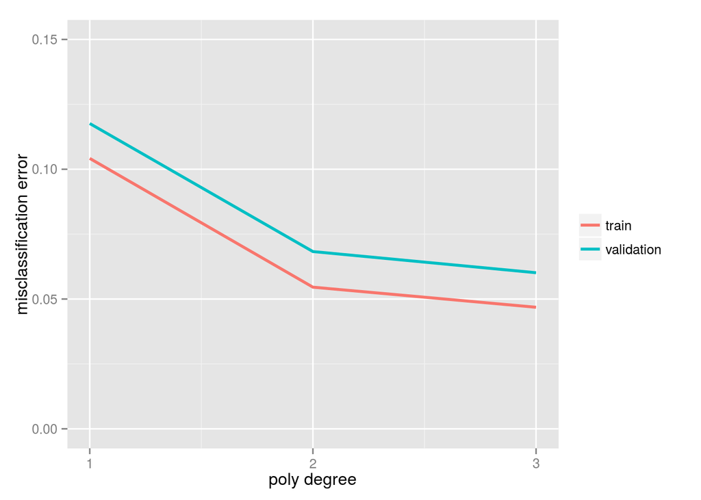

### QDA conclusions

Misclassification error shows that for given data QDA models are much better than LDA models. And as we lift our model to degree 3 this study get very good results for validation. From validation error it shown that more degrees does not lead to overfitting. Here we managed to achieve misclassification error less than 0.5, but this study shows that even better results can be achieved with non-linear models.

Metrix

[output not shown]

Confusion matrix

|  | A | B | C | D | E |
| --- | --- | --- | --- | --- | --- |
| A | 1351 | 28 | 0 | 0 | 0 |
| B | 37 | 898 | 16 | 1 | 9 |
| C | 8 | 13 | 811 | 80 | 36 |
| D | 0 | 0 | 3 | 705 | 20 |
| E | 1 | 6 | 2 | 5 | 876 |

## Random forest

This study goes to nonlienar models. First Random forest will be tried.

Here is code for training data with Random forest.

```r
rf.model <- randomForest(
    classe ~ .,
    mtry = 10,
    data = dplyr::select(train.table,c(1:48,{48*poly.degree+1})) )

prediction.rf.train <- predict(rf.model,newdata=train.table)
prediction.rf.validation <- predict(rf.model,newdata=validation.table)

rf.model.CM.train <- confusionMatrix(prediction.rf.train,train.table$classe)
rf.model.CM.validation <- confusionMatrix(prediction.rf.validation,validation.table$classe)
```

### Random forest results

As we see for training table it fits data almost perfectly. This could lead us to overfitting.

Metrix for training

[output not shown]

Confusion matrix

|  | A | B | C | D | E |
| --- | --- | --- | --- | --- | --- |
| A | 4183 | 0 | 0 | 0 | 0 |
| B | 0 | 2852 | 0 | 0 | 0 |
| C | 0 | 0 | 2590 | 0 | 0 |
| D | 0 | 0 | 0 | 2425 | 0 |
| E | 0 | 0 | 0 | 0 | 2666 |

Misclasfication error for vaidation set is small, so Random forest model is good.

Metrix for validation

| Accuracy | Kappa | AccuracyLower | AccuracyUpper | AccuracyNull | AccuracyPValue | McnemarPValue |
| --- | --- | --- | --- | --- | --- | --- |
| 0.994 | 0.993 | 0.992 | 0.996 | 0.285 | 0 | NaN |

Confusion matrix

|  | A | B | C | D | E |
| --- | --- | --- | --- | --- | --- |
| A | 1397 | 6 | 0 | 0 | 0 |
| B | 0 | 938 | 3 | 0 | 0 |
| C | 0 | 1 | 826 | 9 | 0 |
| D | 0 | 0 | 3 | 780 | 4 |
| E | 0 | 0 | 0 | 2 | 937 |

### Importance of variables

Importance of variables for classification using random forest. They are presented here graphically. And show only 10 important variables.

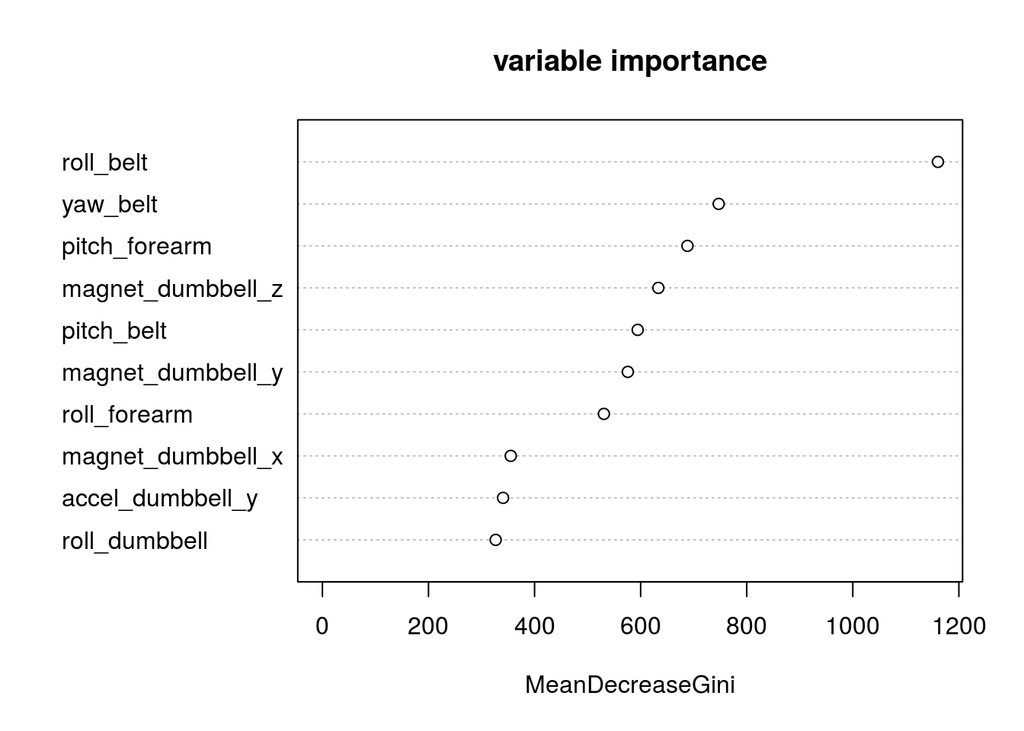

### Random forest conclusions

Random forest is much more better for predicting and outcomes the linear models. It predicts data with less than 0.01 misclassification error and for this data it is very powerfull.

### Boost model

Here is model and predictions for that method.

```r
boost.model <- gbm(classe ~ .,
                   data = dplyr::select(train.table,c(1:{48},{91},{48*poly.degree+1})) ,
                   distribution="multinomial",
                   n.trees = 1000,
                   shrinkage = 0.01,
                   interaction.depth = 4,
                )

prediction.boost.train <- predict(boost.model,newdata=train.table,n.trees = 2000, type="response")
prediction.boost.train.nr <- data.frame(classNr = apply(prediction.boost.train, 1, which.max))
prediction.boost.train.class <- prediction.boost.train.nr %>%
    dplyr::mutate(
        classe=ifelse(
                classNr==1,
                "A",
                ifelse(
                    classNr==2,
                    "B",
                    ifelse(
                        classNr==3,
                        "C",
                        ifelse(
                            classNr==4,
                            "D",
                            "E")
                    )
                )
            )
        )


prediction.boost.validation <- predict(
    boost.model,newdata=validation.table,
    n.trees = 1000, type="response")
prediction.boost.validation.nr <- data.frame(classNr = apply(prediction.boost.validation, 1, which.max))
prediction.boost.validation.class <- prediction.boost.validation.nr %>%
    dplyr::mutate(
        classe=ifelse(
            classNr==1,
            "A",
            ifelse(
                classNr==2,
                "B",
                ifelse(
                    classNr==3,
                    "C",
                    ifelse(
                        classNr==4,
                        "D",
                        "E")
                )
            )
        )
    )



boost.model.CM.train <- confusionMatrix(
    prediction.boost.train.class$classe,
    train.table$classe)

boost.model.CM.validation <- confusionMatrix(
    prediction.boost.validation.class$classe,
    validation.table$classe)
```

### Boost method results

Here we have misclassification error for training.

| Accuracy | Kappa | AccuracyLower | AccuracyUpper | AccuracyNull | AccuracyPValue | McnemarPValue |
| --- | --- | --- | --- | --- | --- | --- |
| 0.974 | 0.968 | 0.972 | 0.977 | 0.284 | 0 | 0 |

Confusion matrix

|  | A | B | C | D | E |
| --- | --- | --- | --- | --- | --- |
| A | 4140 | 63 | 0 | 1 | 3 |
| B | 30 | 2733 | 58 | 6 | 20 |
| C | 7 | 55 | 2510 | 55 | 16 |
| D | 4 | 1 | 19 | 2351 | 21 |
| E | 2 | 0 | 3 | 12 | 2606 |

It looks like this study get very good results for training and this could lead to overfitting. But for validation set this study gets also a very good result.

Metrix for validation

| Accuracy | Kappa | AccuracyLower | AccuracyUpper | AccuracyNull | AccuracyPValue | McnemarPValue |
| --- | --- | --- | --- | --- | --- | --- |
| 0.959 | 0.948 | 0.953 | 0.964 | 0.285 | 0 | 0.001 |

Confusion matrix

|  | A | B | C | D | E |
| --- | --- | --- | --- | --- | --- |
| A | 1372 | 36 | 0 | 2 | 2 |
| B | 18 | 875 | 24 | 4 | 9 |
| C | 5 | 31 | 792 | 28 | 3 |
| D | 2 | 2 | 16 | 751 | 13 |
| E | 0 | 1 | 0 | 6 | 914 |

### Boost inference

Here 10 most inferencial variables are shown.

| var | rel.inf |
| --- | --- |
| roll_belt | 22.189 |
| pitch_forearm | 11.475 |
| yaw_belt | 8.743 |
| magnet_dumbbell_y | 6.646 |
| magnet_dumbbell_z | 6.594 |
| roll_forearm | 4.623 |
| magnet_belt_z | 4.248 |
| pitch_belt | 3.449 |
| roll_dumbbell | 3.077 |
| gyros_belt_z | 2.852 |

Boost methos performs worse than Random forest. Acctually I managed to perform the same accuracy like random forest with n.tree option = 2000, but training process took long time. So for this data random forest model outperforms boost model.

## Conclusion

This study tried to show various mashine learning methods. It looks like, that for this data non linear models are much competitive than linear. Also it can be extend with more models not covered in this study like Regularized Discriminant Analysis or Neural Network.  
For this data this study recomends using Random forest. Because trainging it is fast and performs outstanding results.  
Boost model goes into second place because it is accurate, but training speed is low.  
The third place goes to QDA model.  
The last is lda model. But this study showed that extending variables (to polynomial model) good results can be achieved.

For every model this study achieved more than 92% accuracy. This is very good result, because we started with LDA which showed only 70 accuracy.